# Predição de votos dos deputados

João Victor Barroso Mafra

11 de dezembro de 2017

```r
library(tidyr)
library(dplyr)
```

```r
library(ggplot2)
library(readr)
library(caret)
library(elasticnet)
```

ANALISANDO OS DADOS INICIAIS:

Observando a distribuição dos votos através de um boxplot, podemos ver que existe um outlier, ou seja, um deputado que obteve muito mais votos que os demais, e isso pode acabar prejudicando a construção de nossos modelos.

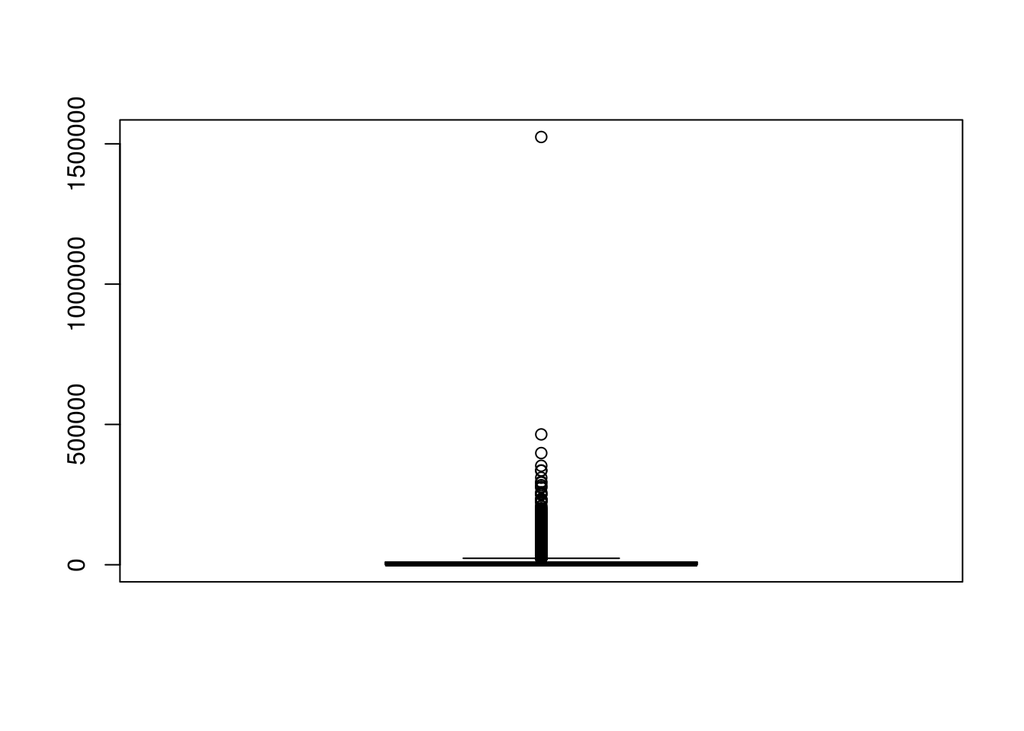

```r
eleicoes2014 <- read.csv("~/workspace/ad2/lab2/eleicoes2014.csv", encoding = "latin1") %>% select(-cargo)

boxplot(eleicoes2014$votos)
```

Assim, será eliminado o deputado que é outlier e ainda variáveis que não influenciam na quantidade de votos de algum parlamentar (id do candidato, seu nome e seu número), assim como variáveis cuja maioria das linhas é composta por valores desconhecidos NA. Feito isso, iniciaremos de fato o treinamento dos modelos.

```r
eleicoes2014 <- eleicoes2014 %>% filter(nome != "CELSO UBIRAJARA RUSSOMANNO")

eleicoes2014.filtered <- eleicoes2014 %>% select(-sequencial_candidato, -nome, -numero_cadidato, -recursos_de_outros_candidatos.comites, -recursos_de_partidos, -recursos_de_pessoas_físicas, -recursos_de_pessoas_juridicas, -recursos_proprios, -setor_economico_receita, -setor_economico_despesa)
```

# 1. Usando todas as variáveis disponíveis, tune (usando validação cruzada): (i) um modelo de regressão Ridge, (ii) um modelo de regressão Lasso e (iii) um modelo KNN. Para os modelos de regressão linear, o parâmetro a ser tunado é o lambda (penalização dos coeficientes) e o KNN o número de vizinhos.

Para todos os modelos, foi utilizada a validação cruzada com 5 blocos. Em relação aos parâmetros a serem tunados, foram utlizados 10 candidatos (no caso da Regressão Ridge e do Lasso é o lâmbda e o no caso do KNN é o número de vizinhos).

REGRESSÃO RIDGE:

Usando a regressão ridge, o lâmbda escolhido foi 0.0421, com um RMSE obtido de 26081.

```r
set.seed(825)

fitControl <- trainControl(method = "cv",
                           number = 5)

ridge.model.cv <- train(votos ~ .,
               data = eleicoes2014.filtered,
               method = "ridge",
               trControl = fitControl,
               tuneLength = 10,
               preProcess = c('scale', 'center'))

ridge.model.cv
```

```
## Ridge Regression
##
## 4151 samples
##   14 predictors
##
## Pre-processing: scaled (77), centered (77)
## Resampling: Cross-Validated (5 fold)
## Summary of sample sizes: 3320, 3322, 3322, 3320, 3320
## Resampling results across tuning parameters:
##
##   lambda        RMSE      Rsquared   MAE
##   0.0000000000  26143.10  0.5645350  12255.74
##   0.0001000000  26143.19  0.5645504  12256.15
##   0.0002371374  26143.37  0.5645655  12256.53
##   0.0005623413  26143.77  0.5645849  12256.78
##   0.0013335214  26143.77  0.5645972  12255.74
##   0.0031622777  26139.49  0.5646155  12250.28
##   0.0074989421  26124.41  0.5647155  12240.37
##   0.0177827941  26098.23  0.5649906  12238.19
##   0.0421696503  26081.69  0.5654429  12260.48
##   0.1000000000  26152.23  0.5659205  12360.13
##
## RMSE was used to select the optimal model using the smallest value.
## The final value used for the model was lambda = 0.04216965.
```

REGRESSÃO LASSO:

Para o Lasso, o lâmbda escolhido foi de 0.3666, que apresentou um RMSE de 26062.97.

```r
set.seed(825)

lasso.model.cv <- train(votos ~ .,
               data = eleicoes2014.filtered,
               method = "lasso",
               trControl = fitControl,
               tuneLength = 10,
               preProcess = c('scale', 'center'))

lasso.model.cv
```

```
## The lasso
##
## 4151 samples
##   14 predictors
##
## Pre-processing: scaled (77), centered (77)
## Resampling: Cross-Validated (5 fold)
## Summary of sample sizes: 3320, 3322, 3322, 3320, 3320
## Resampling results across tuning parameters:
##
##   fraction   RMSE      Rsquared   MAE
##   0.1000000  29054.60  0.5164825  15432.03
##   0.1888889  26478.21  0.5534999  11945.46
##   0.2777778  26141.88  0.5598303  11600.44
##   0.3666667  26062.97  0.5636548  11798.00
##   0.4555556  26123.76  0.5636137  11989.43
##   0.5444444  26188.56  0.5630614  12127.37
##   0.6333333  26188.14  0.5634836  12168.53
##   0.7222222  26177.53  0.5638654  12194.66
##   0.8111111  26160.41  0.5642262  12216.78
##   0.9000000  26149.83  0.5644411  12235.08
##
## RMSE was used to select the optimal model using the smallest value.
## The final value used for the model was fraction = 0.3666667.
```

```r
lasso.model.cv$finalModel
```

[output not shown]

REGRESSÃO KNN:

```r
set.seed(825)

knn.model.cv <- train(votos ~ .,
               data = eleicoes2014.filtered,
               method = "knn",
               trControl = fitControl,
               tuneLength = 10,
               preProcess = c('scale', 'center'))

knn.model.cv
```

```
## k-Nearest Neighbors
##
## 4151 samples
##   14 predictors
##
## Pre-processing: scaled (77), centered (77)
## Resampling: Cross-Validated (5 fold)
## Summary of sample sizes: 3320, 3322, 3322, 3320, 3320
## Resampling results across tuning parameters:
##
##   k   RMSE      Rsquared   MAE
##    5  29075.82  0.4509687  13161.43
##    7  28518.12  0.4687596  12927.48
##    9  28117.28  0.4831998  12747.03
##   11  28130.50  0.4854417  12855.81
##   13  28183.46  0.4848008  13008.77
##   15  28217.16  0.4839568  13077.72
##   17  28279.37  0.4839228  13099.28
##   19  28389.26  0.4813369  13186.84
##   21  28522.50  0.4777990  13246.86
##   23  28684.47  0.4723024  13307.48
##
## RMSE was used to select the optimal model using the smallest value.
## The final value used for the model was k = 9.
```

# 2. Compare os três modelos em termos do erro RMSE de validação cruzada.

O modelo com menor erro quadrático médio foi o gerado pela Regressão Lasso. Em seguida, com um erro muito próximo, vem o modelo gerado pelo Ridge e por último, o modelo gerado pela Regressão KNN, com erro quadrático médio maior que os outros dois.

# 3. Quais as variáveis mais importantes segundo o modelo de regressão Ridge e Lasso? Variáveis foram descartadas pelo Lasso? Quais?

Os dois modelos nos fornecem o mesmo resultado para a importância das variáveis. Temos que as mais importantes foram o total da receita do candidato (com overall igual a 100) e o total de despesas do mesmo (com overall igual a 97). Em seguida, um pouco mais distantes das duas primeiras, aparecem a quantidade de despesas (com overall 57) e a quantidade de doações que o deputado recebeu (overall igual a 51).

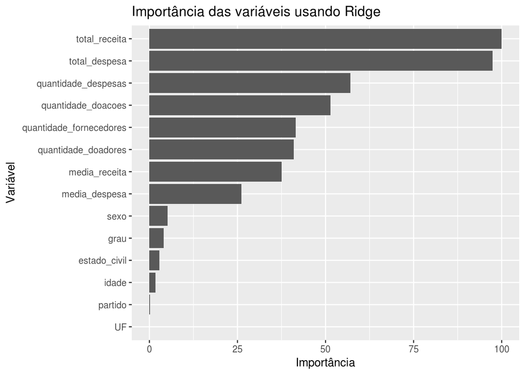

```r
ggplot(varImp(ridge.model.cv)) +
  geom_bar(stat="identity") +
  labs(title="Importância das variáveis usando Ridge", y="Importância", x="Variável")
```

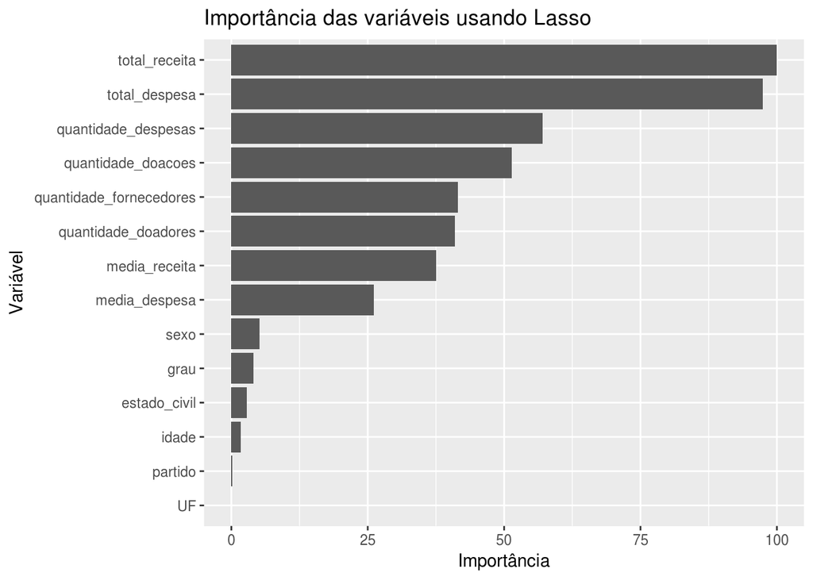

```r
ggplot(varImp(lasso.model.cv)) +
  geom_bar(stat="identity") +
  labs(title="Importância das variáveis usando Lasso", y="Importância", x="Variável")
```

```r
coefficients.lasso.model <- predict.enet(lasso.model.cv$finalModel, type='coefficients', s=lasso.model.cv$bestTune$fraction, mode='fraction')$coefficients

coefficients.lasso.model <- as.data.frame(coefficients.lasso.model)

coefficients.lasso.model
```

```
##                                       coefficients.lasso.model
## UFAL                                                   0.00000
## UFAM                                                 260.14514
## UFAP                                                -754.97915
## UFBA                                                 555.51852
## UFCE                                                1026.72261
## UFDF                                                -531.68587
## UFES                                                   0.00000
## UFGO                                                -273.06771
## UFMA                                                 673.65729
## UFMG                                                   0.00000
## UFMS                                                -844.84986
## UFMT                                                -156.26244
## UFPA                                                 857.04237
## UFPB                                                1009.84234
## UFPE                                                 875.86905
## UFPI                                                   0.00000
## UFPR                                                 481.26853
## UFRJ                                                -522.35665
## UFRN                                                 656.00813
## UFRO                                                -793.40577
## UFRR                                                -767.75150
## UFRS                                                 530.75693
## UFSC                                                 681.44508
## UFSE                                                 375.05058
## UFSP                                                   0.00000
## UFTO                                                -325.98182
## partidoPCB                                             0.00000
## partidoPC do B                                      -291.06848
## partidoPCO                                             0.00000
## partidoPDT                                             0.00000
## partidoPEN                                          -418.99613
## partidoPHS                                          -144.71121
## partidoPMDB                                         1078.30010
## partidoPMN                                          -469.01009
## partidoPP                                            583.78201
## partidoPPL                                          -379.54419
## partidoPPS                                             0.00000
## partidoPR                                            431.10393
## partidoPRB                                           151.74358
```

[output cut: 23 more lines]

```
## quantidade_fornecedores                            -3717.88977
## total_despesa                                          0.00000
## media_despesa                                       2725.14029
## idade                                                  0.00000
## sexoMASCULINO                                       1521.06207
## grauENSINO FUNDAMENTAL INCOMPLETO                      0.00000
## grauENSINO MÉDIO COMPLETO                              0.00000
## grauENSINO MÉDIO INCOMPLETO                            0.00000
## grauLÊ E ESCREVE                                       0.00000
## grauSUPERIOR COMPLETO                               1567.28956
## grauSUPERIOR INCOMPLETO                             -205.92880
## estado_civilDIVORCIADO(A)                              0.00000
## estado_civilSEPARADO(A) JUDICIALMENTE               -598.88966
## estado_civilSOLTEIRO(A)                             -240.60279
## estado_civilVIÚVO(A)                                -663.33752
```